# Pokemon Unit 3 Project

May 10, 2021

**To:** Dr. Random

**From:** Adam Santilli, Christian Cruz, Jessica Vo, Elaine Tse

**Subject:** Statistical Analysis using Chi-Square, ANOVA, and Linear Regression Models

## Analyses

```r
#Read in Pokemon csv and assign all missing information as NA values
#pokemon_data <- read.csv(file.choose(), header=TRUE, na.strings = c("", "NA", "#N/A"),stringsAsFactors = FALSE)
pokemon_data <- read.csv(file.choose(), header = T)
#Remove NA values to get clean data
#pokemon_data <- na.omit(pokemon_data)
```

### Analysis 1: Chi-Square Test of Independence (Generation and Legendary)

#### Analyst: Jessica Vo

The explanatory variables is Generation and the response variable is Legendary. Since you cannot have more than 4 categories for the variables for a Chi-Square Independence test, I had combined generations 1, 2, and 3 into one category representing the early generations and generations 4, 5, and 6 into one category representing the later generations. I grouped them this way because I wanted to see if being in the early generation or later generation has an effect on whether a Pokemon is legendary.

```r
# Combining categories for the Generation variable into 2 categories (EarlyGen and LateGen)
NewGen <- pokemon_data$Generation
NewGen[NewGen %in% c ("1", "2", "3")] <- "EarlyGen"
NewGen[NewGen %in% c ("4", "5", "6")] <- "LateGen"
NewGen <- as.factor(NewGen)
levels(NewGen)
```

```
[1] "EarlyGen" "LateGen"
```

```r
# Table representing the 2 variables
pokemon_matrix <- table(NewGen, pokemon_data$Legendary)
pokemon_matrix
```

```
NewGen     False True
  EarlyGen   403   29
  LateGen    332   36
```

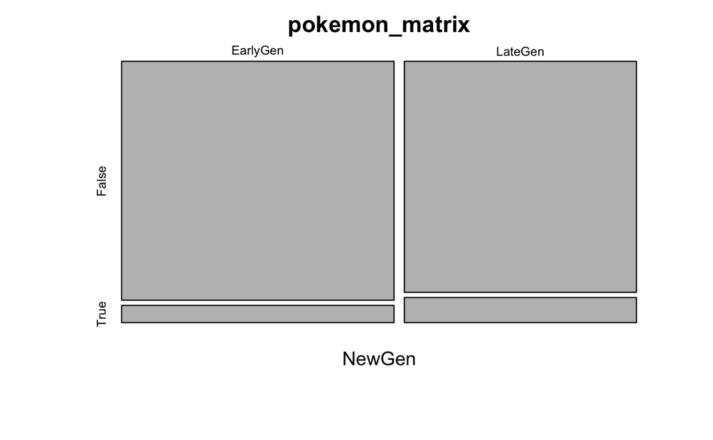

```r
# Mosaic Plot of chosen data (visual representation of variables)
mosaicplot(pokemon_matrix)
```

Conditions:

1. Independence: This condition is not really met since the sample is not a random sample and consists of pretty much all of the Pokemons from generations 1 to 6.
2. Sample size: Each cell has at least 5 expected cases, therefore the sample size condition is met.
3. 2 or more categories for each variable: This condition is met since there are 2 categories for each of the variables chosen.

Null Hypothesis: Pokemon Generation and the Legendary status of Pokemons are independent.

Alternative Hypothesis: Pokemon Generation and the Legendary status of Pokemons are not independent.

```r
chisq.test(pokemon_matrix)
```

```
    Pearson's Chi-squared test with Yates' continuity correction

data:  pokemon_matrix
X-squared = 2.114, df = 1, p-value = 0.146
```

Test statistic = 2.114

P-value = 0.146

Conclusion: Since the p-value is greater than 0.05, we fail to reject the null hypothesis. The data does not provide convincing evidence that Pokemon generation and the legendary status of Pokemons are dependent. It doesn’t appear that the legendary status of Pokemons vary by Pokemon generations.

Limitations: One of the conditions for the the Chi-Square Test of Independence was not met. The independence condition was not really met, therefore this is a limitation to the analysis, since not all the conditions weren’t met, the output might not be as reliable.

### Analysis 2: Analysis of Variance (Speed and Type 1)

#### Analyst: Adam Santilli

```r
library(sjstats)
library(pwr)
library (dplyr)
```

```r
dim(pokemon_data)
```

```
[1] 800  13
```

```r
head(pokemon_data)
```

|  | X. | Name | Type.1 | Type.2 | Total | HP | Attack | Defense | Sp..Atk | Sp..Def | Speed | Generation | Legendary |
| --- | --- | --- | --- | --- | --- | --- | --- | --- | --- | --- | --- | --- | --- |
| 1 | 1 | Bulbasaur | Grass | Poison | 318 | 45 | 49 | 49 | 65 | 65 | 45 | 1 | False |
| 2 | 2 | Ivysaur | Grass | Poison | 405 | 60 | 62 | 63 | 80 | 80 | 60 | 1 | False |
| 3 | 3 | Venusaur | Grass | Poison | 525 | 80 | 82 | 83 | 100 | 100 | 80 | 1 | False |
| 4 | 3 | VenusaurMega Venusaur | Grass | Poison | 625 | 80 | 100 | 123 | 122 | 120 | 80 | 1 | False |
| 5 | 4 | Charmander | Fire |  | 309 | 39 | 52 | 43 | 60 | 50 | 65 | 1 | False |
| 6 | 5 | Charmeleon | Fire |  | 405 | 58 | 64 | 58 | 80 | 65 | 80 | 1 | False |

```r
tail(pokemon_data)
```

|  | X. | Name | Type.1 | Type.2 | Total | HP | Attack | Defense | Sp..Atk | Sp..Def | Speed | Generation | Legendary |
| --- | --- | --- | --- | --- | --- | --- | --- | --- | --- | --- | --- | --- | --- |
| 795 | 718 | Zygarde50% Forme | Dragon | Ground | 600 | 108 | 100 | 121 | 81 | 95 | 95 | 6 | True |
| 796 | 719 | Diancie | Rock | Fairy | 600 | 50 | 100 | 150 | 100 | 150 | 50 | 6 | True |
| 797 | 719 | DiancieMega Diancie | Rock | Fairy | 700 | 50 | 160 | 110 | 160 | 110 | 110 | 6 | True |
| 798 | 720 | HoopaHoopa Confined | Psychic | Ghost | 600 | 80 | 110 | 60 | 150 | 130 | 70 | 6 | True |
| 799 | 720 | HoopaHoopa Unbound | Psychic | Dark | 680 | 80 | 160 | 60 | 170 | 130 | 80 | 6 | True |
| 800 | 721 | Volcanion | Fire | Water | 600 | 80 | 110 | 120 | 130 | 90 | 70 | 6 | True |

```r
NA
```

I am investigating if there is a significant statistical difference in the speed of the 4 main Type 1 Pokemon. The explanatory variable is the 4 different Type 1 classifications, while the speed statistic is the response variable.

```r
## creating the table with the 4 most common pokemon type 1 and the speed variable
pokemon_common <- subset(pokemon_data[c(1:3,11)], pokemon_data$Type.1 == "Grass" | pokemon_data$Type.1 == "Bug"
                         | pokemon_data$Type.1 == "Water" | pokemon_data$Type.1 == "Normal")
summary(pokemon_common)
```

```
       X.            Name              Type.1              Speed
 Min.   :  1.0   Length:349         Length:349         Min.   :  5.00
 1st Qu.:160.0   Class :character   Class :character   1st Qu.: 45.00
 Median :298.0   Mode  :character   Mode  :character   Median : 64.00
 Mean   :322.2                                         Mean   : 65.88
 3rd Qu.:493.0                                         3rd Qu.: 85.00
 Max.   :693.0                                         Max.   :160.00
```

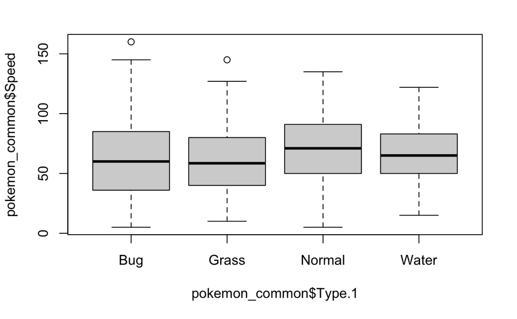

```r
boxplot(pokemon_common$Speed ~ pokemon_common$Type.1)
```

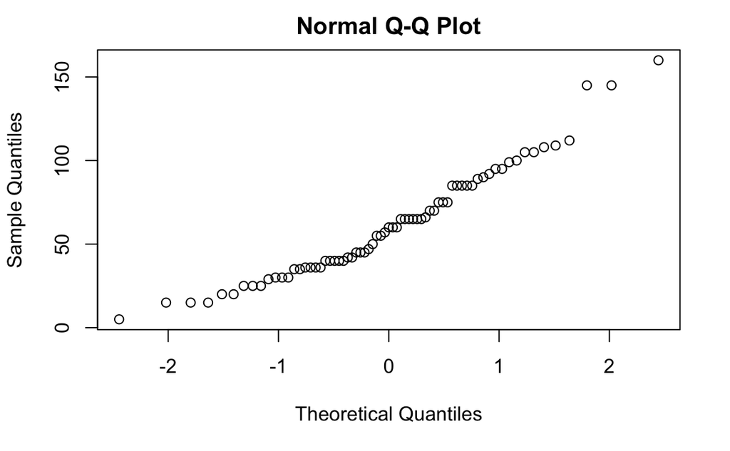

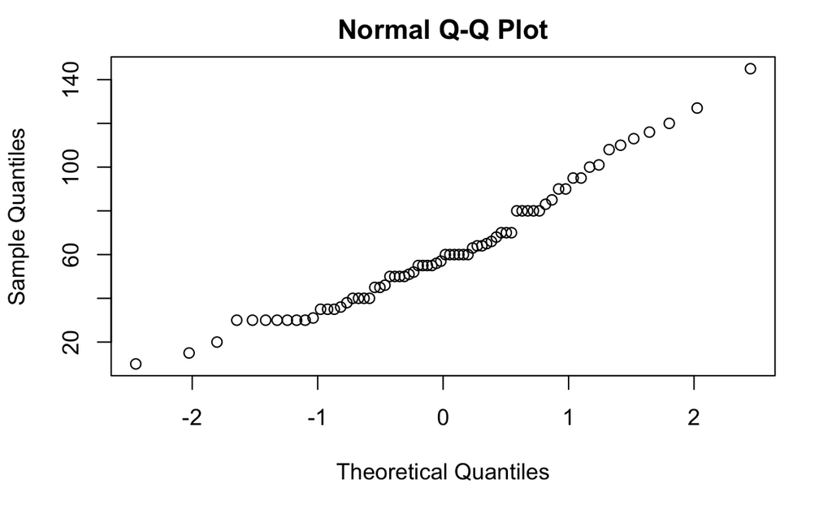

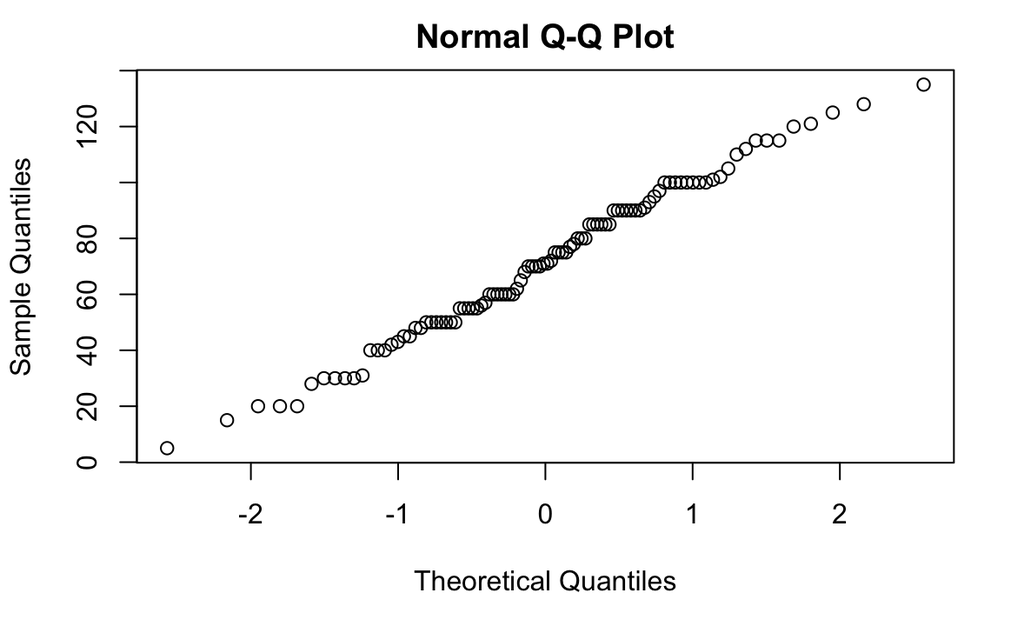

[output not shown]

[output cut: 88 more lines]

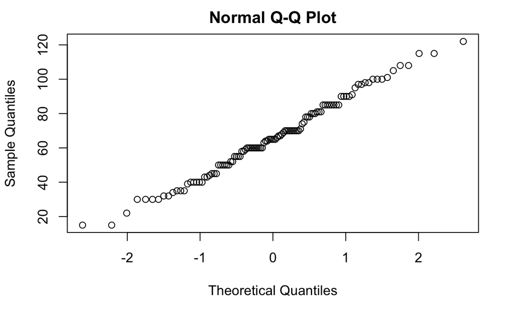

```r
## Checking for ANOVA assumptions

## Normality
tapply(pokemon_common$Speed, pokemon_common$Type.1, qqnorm)
```

```r
## Homogeneity
leveneTest(pokemon_common$Speed ~ pokemon_common$Type.1, data = pokemon_common)
```

```
group coerced to factor.
```

```
Levene's Test for Homogeneity of Variance (center = median)
       Df F value  Pr(>F)
group   3  3.7872 0.01072 *
      345
---
Signif. codes:  0 ‘***’ 0.001 ‘**’ 0.01 ‘*’ 0.05 ‘.’ 0.1 ‘ ’ 1
```

The NULL hypothesis is that there is no difference of means between the 4 different Type 1 Pokemon with respect to the Speed statistic. The alternative hypothesis is that the means of the speed of Type 1 Pokemon are not all the same.

```r
## Running the ANOVA test
aov.all <- aov(pokemon_common$Speed ~ pokemon_common$Type.1, data = pokemon_common)
summary (aov.all)
```

```
                       Df Sum Sq Mean Sq F value Pr(>F)
pokemon_common$Type.1   3   5462  1820.7   2.342  0.073 .
Residuals             345 268236   777.5
---
Signif. codes:  0 ‘***’ 0.001 ‘**’ 0.01 ‘*’ 0.05 ‘.’ 0.1 ‘ ’ 1
```

The test statistic (F-value) is 2.342 and the P-value is 0.073. These values lead me to accept the NULL hypothesis of there being no significant difference in the mean Speed value of the 4 most common Pokemon Types. This means that the most populated Type 1 categories do not have very different mean speed statistics. Calculating the power of this ANOVA test results in a power value of 0.89, which says that this test is a good and valid test to use.

```r
## Calculating the power for this ANOVA test
effectsize::eta_squared(aov.all)
```

```
For one-way between subjects designs, partial eta squared is equivalent to eta squared.
Returning eta squared.
```

```
Parameter             | Eta2 |       90% CI
-------------------------------------------
pokemon_common$Type.1 | 0.02 | [0.00, 0.04]
```

```r
pwr.anova.test(k=4, sig.level=0.05, f=.20, n=87.25, power=NULL)
```

```
     Balanced one-way analysis of variance power calculation

              k = 4
              n = 87.25
              f = 0.2
      sig.level = 0.05
          power = 0.8914849

NOTE: n is number in each group
```